# Importing Required Libraries

```python
import pandas as pd
import numpy as np
import matplotlib.pyplot as plt
import seaborn as sns
import warnings
warnings.filterwarnings('ignore')
import missingno as ms
%matplotlib inline
import warnings
warnings.filterwarnings('ignore')
from sklearn.ensemble import RandomForestClassifier,AdaBoostClassifier,BaggingClassifier,GradientBoostingClassifier
from sklearn.model_selection import train_test_split,GridSearchCV,KFold,cross_val_score
from sklearn.neighbors import KNeighborsClassifier
from sklearn.tree import DecisionTreeClassifier
from sklearn.metrics import cohen_kappa_score,plot_confusion_matrix,accuracy_score,mean_absolute_error,roc_curve,plot_roc_curve,roc_auc_score,mean_absolute_percentage_error,r2_score,mean_squared_error,recall_score,precision_score,classification_report
```

## Read the Datasets using Pandas

```python
df1 = pd.read_csv('Branch_ID_Master.csv')
df2 = pd.read_csv('Loan_Details_transactions.csv')
df3 = pd.read_csv('Loan_status_mapping.csv')
df4 = pd.read_excel('City_Master.xlsx')
df5 = pd.read_excel('Postal_Code_Master.xlsx')
df6 = pd.read_excel('Region_Master.xlsx')
df7 = pd.read_excel('State_Master.xlsx')
df8 = pd.read_excel('State_Region_Mapping.xlsx')
```

## Make the column names equal where the values are same

after checking all the columns of datasets, I found there are similar columns with different names, then I used rename function to make equal names.

```python
df1.rename(columns={'Region_Code':'Region_ID'}, inplace=True)
```

```python
df8.rename(columns={'State Name':'State_Name','Region':'Region_Name'}, inplace=True)
```

```python
df1.columns
```

```
Index(['Branch_Id', 'Region_ID'], dtype='object')
```

```python
df2.columns
```

```
Index(['Loan_Id', 'Disbursed_Amount', 'Asset_Cost', 'ltv', 'Branch_Id',
       'City_Code', 'State_Code', 'Postal_Code', 'Date_of_Birth',
       'Employment_Type', 'DisbursalDate', 'MobileNo_Avl_Flag', 'Aadhar_flag',
       'PAN_flag', 'VoterID_flag', 'Driving_flag', 'Passport_flag',
       'PERFORM_CNS.SCORE', 'DELINQUENT.ACCTS.IN.LAST.SIX.MONTHS',
       'CREDIT.HISTORY.LENGTH', 'NO.OF_INQUIRIES'],
      dtype='object')
```

```python
df3.columns
```

```
Index(['Loan_Id', 'Loan_Default'], dtype='object')
```

```python
df4.columns
```

```
Index(['City_Code', 'State_Code', 'City_Name'], dtype='object')
```

```python
df5.columns
```

```
Index(['City_Code', 'City_Name', 'Postal_Code'], dtype='object')
```

```python
df6.columns
```

```
Index(['Region_ID', 'Region_Name'], dtype='object')
```

```python
df7.columns
```

```
Index(['State_Code', 'State_Name'], dtype='object')
```

```python
df8.columns
```

```
Index(['Region_Name', 'State_Name', 'Region_ID', 'State_Code'], dtype='object')
```

## I tried with concate function to combine all the datasets but it is not merging the columns, just coping the data sets one after one. Due to this its creating n number of nans.

## Finally I found the merge function, it is removing the all duplicates and merging the columns.

# Merge all data sets in to one, by the order of matching features

After I tried with all possibilites I found this proper order to merge the all datasets in to one

```python
df = pd.merge(df7,df8)
df = pd.merge(df,df6)
df = pd.merge(df,df4)
df = pd.merge(df,df5)
df = pd.merge(df,df2)
df = pd.merge(df,df3)
df = pd.merge(df,df1)
```

```python
df
```

|  | State_Code | State_Name | Region_Name | Region_ID | City_Code | City_Name | Postal_Code | Loan_Id | Disbursed_Amount | Asset_Cost | ... | Aadhar_flag | PAN_flag | VoterID_flag | Driving_flag | Passport_flag | PERFORM_CNS.SCORE | DELINQUENT.ACCTS.IN.LAST.SIX.MONTHS | CREDIT.HISTORY.LENGTH | NO.OF_INQUIRIES | Loan_Default |
| --- | --- | --- | --- | --- | --- | --- | --- | --- | --- | --- | --- | --- | --- | --- | --- | --- | --- | --- | --- | --- | --- |
| 0 | ST01 | Andhra Pradesh | South | R2 | CT25 | Nellore | 524225 | 194 | 57213 | 71957 | ... | 1 | 0 | 0 | 0 | 0 | 0 | 0 | 0yrs 0mon | 0 | 1 |
| 1 | ST01 | Andhra Pradesh | South | R2 | CT25 | Nellore | 524225 | 2285 | 45659 | 85309 | ... | 1 | 0 | 0 | 0 | 0 | 738 | 0 | 3yrs 3mon | 0 | 0 |
| 2 | ST01 | Andhra Pradesh | South | R2 | CT25 | Nellore | 524225 | 4485 | 56759 | 76843 | ... | 1 | 0 | 0 | 0 | 0 | 0 | 0 | 0yrs 0mon | 0 | 0 |
| 3 | ST01 | Andhra Pradesh | South | R2 | CT25 | Nellore | 524225 | 14129 | 53612 | 93612 | ... | 1 | 0 | 0 | 0 | 0 | 17 | 0 | 0yrs 2mon | 0 | 0 |
| 4 | ST01 | Andhra Pradesh | South | R2 | CT25 | Nellore | 524225 | 19639 | 55259 | 76351 | ... | 1 | 0 | 0 | 0 | 0 | 0 | 0 | 0yrs 0mon | 0 | 1 |
| ... | ... | ... | ... | ... | ... | ... | ... | ... | ... | ... | ... | ... | ... | ... | ... | ... | ... | ... | ... | ... | ... |
| 4834 | ST34 | Delhi | North | R1 | CT09 | Delhi | 110039 | 1346 | 46349 | 62175 | ... | 0 | 0 | 1 | 0 | 0 | 0 | 0 | 0yrs 0mon | 0 | 0 |
| 4835 | ST34 | Delhi | North | R1 | CT09 | Delhi | 110039 | 4696 | 39239 | 56823 | ... | 1 | 0 | 0 | 0 | 0 | 726 | 0 | 0yrs 11mon | 0 | 0 |
| 4836 | ST34 | Delhi | North | R1 | CT09 | Delhi | 110039 | 19519 | 47349 | 57917 | ... | 1 | 0 | 0 | 0 | 0 | 300 | 1 | 5yrs 5mon | 0 | 0 |
| 4837 | ST34 | Delhi | North | R1 | CT09 | Delhi | 110039 | 12709 | 51931 | 65785 | ... | 1 | 0 | 0 | 0 | 0 | 0 | 0 | 0yrs 0mon | 1 | 1 |
| 4838 | ST34 | Delhi | North | R1 | CT09 | Delhi | 110039 | 16272 | 40894 | 64178 | ... | 1 | 0 | 0 | 0 | 0 | 424 | 0 | 3yrs 6mon | 0 | 1 |

4839 rows × 26 columns

```python
df.columns
```

```
Index(['State_Code', 'State_Name', 'Region_Name', 'Region_ID', 'City_Code',
       'City_Name', 'Postal_Code', 'Loan_Id', 'Disbursed_Amount', 'Asset_Cost',
       'ltv', 'Branch_Id', 'Date_of_Birth', 'Employment_Type', 'DisbursalDate',
       'MobileNo_Avl_Flag', 'Aadhar_flag', 'PAN_flag', 'VoterID_flag',
       'Driving_flag', 'Passport_flag', 'PERFORM_CNS.SCORE',
       'DELINQUENT.ACCTS.IN.LAST.SIX.MONTHS', 'CREDIT.HISTORY.LENGTH',
       'NO.OF_INQUIRIES', 'Loan_Default'],
      dtype='object')
```

## set the features in required order

```python
df = df.reindex(['Branch_Id', 'Loan_Id', 'Region_Name', 'State_Name', 'City_Name', 'Employment_Type', 'Region_ID', 'State_Code', 'City_Code',
       'Postal_Code', 'Date_of_Birth', 'DisbursalDate',
       'MobileNo_Avl_Flag', 'Aadhar_flag', 'PAN_flag', 'VoterID_flag',
       'Driving_flag', 'Passport_flag',  'CREDIT.HISTORY.LENGTH', 'DELINQUENT.ACCTS.IN.LAST.SIX.MONTHS', 'Disbursed_Amount', 'Asset_Cost',
       'ltv', 'PERFORM_CNS.SCORE', 'NO.OF_INQUIRIES', 'Loan_Default'], axis=1)
```

```python
df.head()
```

|  | Branch_Id | Loan_Id | Region_Name | State_Name | City_Name | Employment_Type | Region_ID | State_Code | City_Code | Postal_Code | ... | Driving_flag | Passport_flag | CREDIT.HISTORY.LENGTH | DELINQUENT.ACCTS.IN.LAST.SIX.MONTHS | Disbursed_Amount | Asset_Cost | ltv | PERFORM_CNS.SCORE | NO.OF_INQUIRIES | Loan_Default |
| --- | --- | --- | --- | --- | --- | --- | --- | --- | --- | --- | --- | --- | --- | --- | --- | --- | --- | --- | --- | --- | --- |
| 0 | 64 | 194 | South | Andhra Pradesh | Nellore | Salaried | R2 | ST01 | CT25 | 524225 | ... | 0 | 0 | 0yrs 0mon | 0 | 57213 | 71957 | 83.38 | 0 | 0 | 1 |
| 1 | 64 | 2285 | South | Andhra Pradesh | Nellore | Salaried | R2 | ST01 | CT25 | 524225 | ... | 0 | 0 | 3yrs 3mon | 0 | 45659 | 85309 | 57.44 | 738 | 0 | 0 |
| 2 | 64 | 4485 | South | Andhra Pradesh | Nellore | Self employed | R2 | ST01 | CT25 | 524225 | ... | 0 | 0 | 0yrs 0mon | 0 | 56759 | 76843 | 74.83 | 0 | 0 | 0 |
| 3 | 64 | 14129 | South | Andhra Pradesh | Nellore | Salaried | R2 | ST01 | CT25 | 524225 | ... | 0 | 0 | 0yrs 2mon | 0 | 53612 | 93612 | 59.82 | 17 | 0 | 0 |
| 4 | 64 | 19639 | South | Andhra Pradesh | Nellore | NaN | R2 | ST01 | CT25 | 524225 | ... | 0 | 0 | 0yrs 0mon | 0 | 55259 | 76351 | 73.35 | 0 | 0 | 1 |

5 rows × 26 columns

## Data Cleaning

```python
df.info()
```

```
<class 'pandas.core.frame.DataFrame'>
Int64Index: 4839 entries, 0 to 4838
Data columns (total 26 columns):
 #   Column                               Non-Null Count  Dtype
---  ------                               --------------  -----
 0   Branch_Id                            4839 non-null   int64
 1   Loan_Id                              4839 non-null   int64
 2   Region_Name                          4839 non-null   object
 3   State_Name                           4839 non-null   object
 4   City_Name                            4839 non-null   object
 5   Employment_Type                      4677 non-null   object
 6   Region_ID                            4839 non-null   object
 7   State_Code                           4839 non-null   object
 8   City_Code                            4839 non-null   object
 9   Postal_Code                          4839 non-null   int64
```

[output cut: 18 more lines]

```python
df.isnull().sum()
```

```
Branch_Id                                0
Loan_Id                                  0
Region_Name                              0
State_Name                               0
City_Name                                0
Employment_Type                        162
Region_ID                                0
State_Code                               0
City_Code                                0
Postal_Code                              0
Date_of_Birth                            0
DisbursalDate                            0
MobileNo_Avl_Flag                        0
Aadhar_flag                              0
PAN_flag                                 0
VoterID_flag                             0
Driving_flag                             0
Passport_flag                            0
CREDIT.HISTORY.LENGTH                    0
DELINQUENT.ACCTS.IN.LAST.SIX.MONTHS      0
Disbursed_Amount                         0
Asset_Cost                               0
ltv                                      0
PERFORM_CNS.SCORE                        0
NO.OF_INQUIRIES                          0
Loan_Default                             0
dtype: int64
```

```python
df.Employment_Type.value_counts()
```

```
Self employed    2587
Salaried         2090
Name: Employment_Type, dtype: int64
```

```python
df.Employment_Type.fillna('Unknown', inplace=True)
```

```python
df.Employment_Type.value_counts()
```

```
Self employed    2587
Salaried         2090
Unknown           162
Name: Employment_Type, dtype: int64
```

```python
df.Employment_Type.isnull().sum()
```

```
0
```

```python
df.info()
```

```
<class 'pandas.core.frame.DataFrame'>
Int64Index: 4839 entries, 0 to 4838
Data columns (total 26 columns):
 #   Column                               Non-Null Count  Dtype
---  ------                               --------------  -----
 0   Branch_Id                            4839 non-null   int64
 1   Loan_Id                              4839 non-null   int64
 2   Region_Name                          4839 non-null   object
 3   State_Name                           4839 non-null   object
 4   City_Name                            4839 non-null   object
 5   Employment_Type                      4839 non-null   object
 6   Region_ID                            4839 non-null   object
 7   State_Code                           4839 non-null   object
 8   City_Code                            4839 non-null   object
 9   Postal_Code                          4839 non-null   int64
```

[output cut: 18 more lines]

```python
df.isnull().sum()
```

```
Branch_Id                              0
Loan_Id                                0
Region_Name                            0
State_Name                             0
City_Name                              0
Employment_Type                        0
Region_ID                              0
State_Code                             0
City_Code                              0
Postal_Code                            0
Date_of_Birth                          0
DisbursalDate                          0
MobileNo_Avl_Flag                      0
Aadhar_flag                            0
PAN_flag                               0
VoterID_flag                           0
Driving_flag                           0
Passport_flag                          0
CREDIT.HISTORY.LENGTH                  0
DELINQUENT.ACCTS.IN.LAST.SIX.MONTHS    0
Disbursed_Amount                       0
Asset_Cost                             0
ltv                                    0
PERFORM_CNS.SCORE                      0
NO.OF_INQUIRIES                        0
Loan_Default                           0
dtype: int64
```

```python
df.duplicated().sum()
```

```
0
```

```python
# df['Date_of_Birth'] = pd.to_datetime(df['Date_of_Birth'])
# df['DisbursalDate'] = pd.to_datetime(df['DisbursalDate'])
```

```python
df.info()
```

```
<class 'pandas.core.frame.DataFrame'>
Int64Index: 4839 entries, 0 to 4838
Data columns (total 26 columns):
 #   Column                               Non-Null Count  Dtype
---  ------                               --------------  -----
 0   Branch_Id                            4839 non-null   int64
 1   Loan_Id                              4839 non-null   int64
 2   Region_Name                          4839 non-null   object
 3   State_Name                           4839 non-null   object
 4   City_Name                            4839 non-null   object
 5   Employment_Type                      4839 non-null   object
 6   Region_ID                            4839 non-null   object
 7   State_Code                           4839 non-null   object
 8   City_Code                            4839 non-null   object
 9   Postal_Code                          4839 non-null   int64
```

[output cut: 18 more lines]

```python
df.T
```

|  | 0 | 1 | 2 | 3 | 4 | 5 | 6 | 7 | 8 | 9 | ... | 4829 | 4830 | 4831 | 4832 | 4833 | 4834 | 4835 | 4836 | 4837 | 4838 |
| --- | --- | --- | --- | --- | --- | --- | --- | --- | --- | --- | --- | --- | --- | --- | --- | --- | --- | --- | --- | --- | --- |
| Branch_Id | 64 | 64 | 64 | 64 | 64 | 64 | 64 | 64 | 64 | 64 | ... | 258 | 258 | 249 | 249 | 207 | 207 | 207 | 207 | 261 | 259 |
| Loan_Id | 194 | 2285 | 4485 | 14129 | 19639 | 22959 | 693 | 6669 | 11703 | 19657 | ... | 5035 | 16628 | 11784 | 14247 | 18625 | 1346 | 4696 | 19519 | 12709 | 16272 |
| Region_Name | South | South | South | South | South | South | South | South | South | South | ... | North | North | North | North | North | North | North | North | North | North |
| State_Name | Andhra Pradesh | Andhra Pradesh | Andhra Pradesh | Andhra Pradesh | Andhra Pradesh | Andhra Pradesh | Karnataka | Karnataka | Karnataka | Karnataka | ... | Delhi | Delhi | Rajasthan | Delhi | Rajasthan | Delhi | Delhi | Delhi | Delhi | Delhi |
| City_Name | Nellore | Nellore | Nellore | Nellore | Nellore | Nellore | Bangalore | Bangalore | Bangalore | Bangalore | ... | Delhi | Delhi | Jaipur | Delhi | Jaipur | Delhi | Delhi | Delhi | Delhi | Delhi |
| Employment_Type | Salaried | Salaried | Self employed | Salaried | Unknown | Self employed | Salaried | Self employed | Self employed | Self employed | ... | Salaried | Self employed | Self employed | Self employed | Salaried | Self employed | Salaried | Self employed | Self employed | Self employed |
| Region_ID | R2 | R2 | R2 | R2 | R2 | R2 | R2 | R2 | R2 | R2 | ... | R1 | R1 | R1 | R1 | R1 | R1 | R1 | R1 | R1 | R1 |
| State_Code | ST01 | ST01 | ST01 | ST01 | ST01 | ST01 | ST12 | ST12 | ST12 | ST12 | ... | ST34 | ST34 | ST22 | ST34 | ST22 | ST34 | ST34 | ST34 | ST34 | ST34 |
| City_Code | CT25 | CT25 | CT25 | CT25 | CT25 | CT25 | CT10 | CT10 | CT10 | CT10 | ... | CT09 | CT09 | CT06 | CT09 | CT06 | CT09 | CT09 | CT09 | CT09 | CT09 |
| Postal_Code | 524225 | 524225 | 524225 | 524225 | 524225 | 524225 | 560034 | 560034 | 560034 | 560034 | ... | 110039 | 110039 | 302029 | 110039 | 302029 | 110039 | 110039 | 110039 | 110039 | 110039 |
| Date_of_Birth | 01-01-1993 | 15-05-1995 | 01-01-1987 | 07-02-1997 | 20-09-1998 | 23-02-1984 | 01-01-1961 | 01-08-1990 | 01-01-1981 | 01-01-1981 | ... | 20-02-1996 | 01-01-1981 | 25-05-1980 | 05-06-1976 | 15-08-1973 | 01-01-1992 | 01-01-1982 | 01-03-1976 | 17-05-1971 | 17-07-1992 |
| DisbursalDate | 08-08-2018 | 25-10-2018 | 07-09-2018 | 24-09-2018 | 23-10-2018 | 23-10-2018 | 30-08-2018 | 27-10-2018 | 25-10-2018 | 10-10-2018 | ... | 30-08-2018 | 31-08-2018 | 21-10-2018 | 23-08-2018 | 22-10-2018 | 30-08-2018 | 29-10-2018 | 28-08-2018 | 28-10-2018 | 23-10-2018 |
| MobileNo_Avl_Flag | 1 | 1 | 1 | 1 | 1 | 1 | 1 | 1 | 1 | 1 | ... | 1 | 1 | 1 | 1 | 1 | 1 | 1 | 1 | 1 | 1 |
| Aadhar_flag | 1 | 1 | 1 | 1 | 1 | 1 | 1 | 1 | 1 | 1 | ... | 1 | 1 | 1 | 1 | 1 | 0 | 1 | 1 | 1 | 1 |
| PAN_flag | 0 | 0 | 0 | 0 | 0 | 0 | 0 | 0 | 0 | 0 | ... | 0 | 0 | 0 | 0 | 0 | 0 | 0 | 0 | 0 | 0 |
| VoterID_flag | 0 | 0 | 0 | 0 | 0 | 0 | 0 | 0 | 0 | 0 | ... | 0 | 0 | 0 | 0 | 0 | 1 | 0 | 0 | 0 | 0 |
| Driving_flag | 0 | 0 | 0 | 0 | 0 | 0 | 0 | 0 | 0 | 0 | ... | 0 | 0 | 0 | 0 | 0 | 0 | 0 | 0 | 0 | 0 |
| Passport_flag | 0 | 0 | 0 | 0 | 0 | 0 | 0 | 0 | 0 | 0 | ... | 0 | 0 | 0 | 0 | 0 | 0 | 0 | 0 | 0 | 0 |
| CREDIT.HISTORY.LENGTH | 0yrs 0mon | 3yrs 3mon | 0yrs 0mon | 0yrs 2mon | 0yrs 0mon | 2yrs 1mon | 1yrs 0mon | 0yrs 0mon | 11yrs 11mon | 2yrs 0mon | ... | 0yrs 0mon | 0yrs 0mon | 0yrs 0mon | 2yrs 11mon | 10yrs 6mon | 0yrs 0mon | 0yrs 11mon | 5yrs 5mon | 0yrs 0mon | 3yrs 6mon |
| DELINQUENT.ACCTS.IN.LAST.SIX.MONTHS | 0 | 0 | 0 | 0 | 0 | 2 | 0 | 0 | 0 | 0 | ... | 0 | 0 | 0 | 0 | 0 | 0 | 0 | 1 | 0 | 0 |
| Disbursed_Amount | 57213 | 45659 | 56759 | 53612 | 55259 | 55259 | 42394 | 47999 | 64369 | 63913 | ... | 70643 | 47349 | 57541 | 48283 | 43894 | 46349 | 39239 | 47349 | 51931 | 40894 |
| Asset_Cost | 71957 | 85309 | 76843 | 93612 | 76351 | 80017 | 69066 | 72182 | 75620 | 74470 | ... | 99891 | 55590 | 67485 | 68379 | 51500 | 62175 | 56823 | 57917 | 65785 | 64178 |
| ltv | 83.38 | 57.44 | 74.83 | 59.82 | 73.35 | 69.99 | 62.26 | 69.27 | 89.92 | 87.28 | ... | 74.08 | 88.15 | 89.35 | 74.58 | 86.41 | 77.2 | 70.04 | 84.6 | 80.0 | 66.22 |
| PERFORM_CNS.SCORE | 0 | 738 | 0 | 17 | 0 | 601 | 825 | 0 | 389 | 758 | ... | 0 | 0 | 0 | 705 | 653 | 0 | 726 | 300 | 0 | 424 |
| NO.OF_INQUIRIES | 0 | 0 | 0 | 0 | 0 | 0 | 0 | 0 | 0 | 1 | ... | 0 | 0 | 0 | 0 | 0 | 0 | 0 | 0 | 1 | 0 |
| Loan_Default | 1 | 0 | 0 | 0 | 1 | 0 | 0 | 1 | 1 | 0 | ... | 1 | 0 | 0 | 0 | 0 | 0 | 0 | 0 | 1 | 1 |

26 rows × 4839 columns

After I cleaned the data I saved it as a csv file for the future reference

```python
df.to_csv('L&T finance.csv',index=False)
```

```python
df1 = pd.read_csv('L&T finance.csv')
df1.head()
```

|  | Branch_Id | Loan_Id | Region_Name | State_Name | City_Name | Employment_Type | Region_ID | State_Code | City_Code | Postal_Code | ... | Driving_flag | Passport_flag | CREDIT.HISTORY.LENGTH | DELINQUENT.ACCTS.IN.LAST.SIX.MONTHS | Disbursed_Amount | Asset_Cost | ltv | PERFORM_CNS.SCORE | NO.OF_INQUIRIES | Loan_Default |
| --- | --- | --- | --- | --- | --- | --- | --- | --- | --- | --- | --- | --- | --- | --- | --- | --- | --- | --- | --- | --- | --- |
| 0 | 64 | 194 | South | Andhra Pradesh | Nellore | Salaried | R2 | ST01 | CT25 | 524225 | ... | 0 | 0 | 0yrs 0mon | 0 | 57213 | 71957 | 83.38 | 0 | 0 | 1 |
| 1 | 64 | 2285 | South | Andhra Pradesh | Nellore | Salaried | R2 | ST01 | CT25 | 524225 | ... | 0 | 0 | 3yrs 3mon | 0 | 45659 | 85309 | 57.44 | 738 | 0 | 0 |
| 2 | 64 | 4485 | South | Andhra Pradesh | Nellore | Self employed | R2 | ST01 | CT25 | 524225 | ... | 0 | 0 | 0yrs 0mon | 0 | 56759 | 76843 | 74.83 | 0 | 0 | 0 |
| 3 | 64 | 14129 | South | Andhra Pradesh | Nellore | Salaried | R2 | ST01 | CT25 | 524225 | ... | 0 | 0 | 0yrs 2mon | 0 | 53612 | 93612 | 59.82 | 17 | 0 | 0 |
| 4 | 64 | 19639 | South | Andhra Pradesh | Nellore | Unknown | R2 | ST01 | CT25 | 524225 | ... | 0 | 0 | 0yrs 0mon | 0 | 55259 | 76351 | 73.35 | 0 | 0 | 1 |

5 rows × 26 columns

## Removing duplicate & unimportant columns

```python
df.drop(columns=['Branch_Id','Region_ID','State_Code','City_Code','Postal_Code','MobileNo_Avl_Flag','Aadhar_flag','PAN_flag','VoterID_flag','Driving_flag','Passport_flag'], inplace=True )
```

```python
df.head()
```

|  | Loan_Id | Region_Name | State_Name | City_Name | Employment_Type | Date_of_Birth | DisbursalDate | CREDIT.HISTORY.LENGTH | DELINQUENT.ACCTS.IN.LAST.SIX.MONTHS | Disbursed_Amount | Asset_Cost | ltv | PERFORM_CNS.SCORE | NO.OF_INQUIRIES | Loan_Default |
| --- | --- | --- | --- | --- | --- | --- | --- | --- | --- | --- | --- | --- | --- | --- | --- |
| 0 | 194 | South | Andhra Pradesh | Nellore | Salaried | 01-01-1993 | 08-08-2018 | 0yrs 0mon | 0 | 57213 | 71957 | 83.38 | 0 | 0 | 1 |
| 1 | 2285 | South | Andhra Pradesh | Nellore | Salaried | 15-05-1995 | 25-10-2018 | 3yrs 3mon | 0 | 45659 | 85309 | 57.44 | 738 | 0 | 0 |
| 2 | 4485 | South | Andhra Pradesh | Nellore | Self employed | 01-01-1987 | 07-09-2018 | 0yrs 0mon | 0 | 56759 | 76843 | 74.83 | 0 | 0 | 0 |
| 3 | 14129 | South | Andhra Pradesh | Nellore | Salaried | 07-02-1997 | 24-09-2018 | 0yrs 2mon | 0 | 53612 | 93612 | 59.82 | 17 | 0 | 0 |
| 4 | 19639 | South | Andhra Pradesh | Nellore | Unknown | 20-09-1998 | 23-10-2018 | 0yrs 0mon | 0 | 55259 | 76351 | 73.35 | 0 | 0 | 1 |

```python
df.columns
```

```
Index(['Loan_Id', 'Region_Name', 'State_Name', 'City_Name', 'Employment_Type',
       'Date_of_Birth', 'DisbursalDate', 'CREDIT.HISTORY.LENGTH',
       'DELINQUENT.ACCTS.IN.LAST.SIX.MONTHS', 'Disbursed_Amount', 'Asset_Cost',
       'ltv', 'PERFORM_CNS.SCORE', 'NO.OF_INQUIRIES', 'Loan_Default'],
      dtype='object')
```

```python
df_num = df[['Disbursed_Amount', 'Asset_Cost', 'ltv', 'PERFORM_CNS.SCORE']]
```

```python
df_num.describe()
```

|  | Disbursed_Amount | Asset_Cost | ltv | PERFORM_CNS.SCORE |
| --- | --- | --- | --- | --- |
| count | 4839.000000 | 4839.000000 | 4839.000000 | 4839.00000 |
| mean | 53894.484604 | 74887.881174 | 75.029570 | 292.93821 |
| std | 12255.716104 | 17703.975444 | 11.429751 | 339.24187 |
| min | 13600.000000 | 39289.000000 | 17.360000 | 0.00000 |
| 25% | 46849.000000 | 65181.500000 | 69.145000 | 0.00000 |
| 50% | 53503.000000 | 70401.000000 | 77.210000 | 15.00000 |
| 75% | 59947.000000 | 78190.500000 | 83.920000 | 679.00000 |
| max | 144085.000000 | 244607.000000 | 94.980000 | 879.00000 |

```python
df.describe(include='O')
```

|  | Region_Name | State_Name | City_Name | Employment_Type | Date_of_Birth | DisbursalDate | CREDIT.HISTORY.LENGTH |
| --- | --- | --- | --- | --- | --- | --- | --- |
| count | 4839 | 4839 | 4839 | 4839 | 4839 | 4839 | 4839 |
| unique | 4 | 14 | 24 | 3 | 3038 | 83 | 168 |
| top | East | Jharkhand | Bhubaneshwar | Self employed | 01-01-1987 | 31-10-2018 | 0yrs 0mon |
| freq | 1811 | 747 | 383 | 2587 | 55 | 175 | 2452 |

```python
df['Loan_Default'].value_counts()
```

```
0    3767
1    1072
Name: Loan_Default, dtype: int64
```

Missing values treated after the Outlier treatment Because Mean value is effected by the outliers. Once outliers treated mean value is doesnt effect by the outliers, then we can use most suitable method to replace the missing Values

# Outlier Treatment

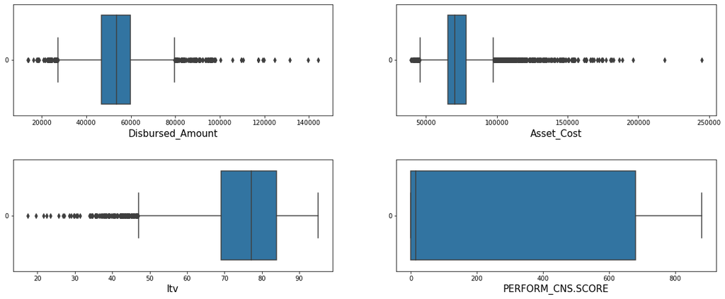

```python
plt.figure(figsize=(20,35))
plt.subplots_adjust(hspace=0.4)
plot_num = 1
for i in df_num.columns:
    ax = plt.subplot(8,2,plot_num)
    sns.boxplot(data=df_num[i],orient='h')
    plt.xlabel(i,fontdict={'fontsize':15})
    plot_num+=1
```

```python
def trans_box(i):
    plt.figure(figsize=(20,8),facecolor='white')
    plt.subplots_adjust(hspace=0.4)
    plt.subplot(2,3,1)
    sns.boxplot(data=df_num[i],orient='h')
    plt.title('Original',fontdict={'fontsize':15})
    plt.xlabel(i,fontdict={'fontsize':15})
    plt.subplot(2,3,2)
    sns.boxplot(data=np.sqrt(df_num[i]),orient='h')
    plt.title('Sqroot',fontdict={'fontsize':15})
    plt.xlabel(i,fontdict={'fontsize':15})
    plt.subplot(2,3,3)
    sns.boxplot(data=(df_num[i])**2,orient='h')
    plt.title('Square',fontdict={'fontsize':15})
    plt.xlabel(i,fontdict={'fontsize':15})
    plt.subplot(2,3,4)
    sns.boxplot(data=np.log(df_num[i]),orient='h')
    plt.title('Log',fontdict={'fontsize':15})
    plt.xlabel(i,fontdict={'fontsize':15})
    plt.subplot(2,3,5)
    sns.boxplot(data=np.cbrt(df_num[i]),orient='h')
    plt.title('Cuberoot',fontdict={'fontsize':15})
    plt.xlabel(i,fontdict={'fontsize':15})
    plt.show()
```

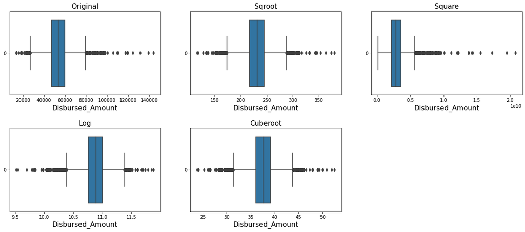

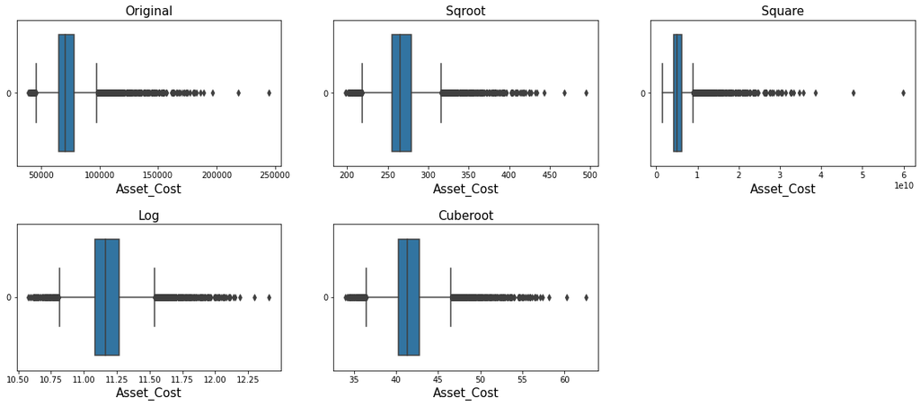

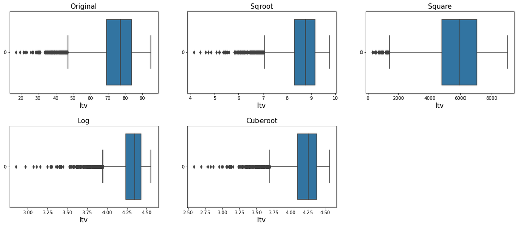

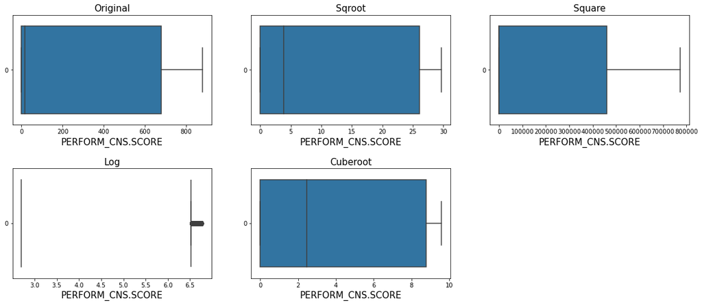

```python
for i in df_num.columns:
    trans_box(i)
```

after checking different transmation techniques there is no much change in outliers

```python
Q1 = df_num.quantile(0.25)
Q3 = df_num.quantile(0.75)
IQR = Q3 - Q1
df_outlier = df_num[((df_num < (Q1 - 1.5 * IQR)) |(df_num > (Q3 + 1.5 * IQR))).any(axis=1)]
print(df_outlier.shape)
```

```
(643, 4)
```

```python
## percentage of Outliers
df_outlier.shape[0]*100/len(df)
```

```
13.287869394502996
```

As the percentage of Outliers is 13.28, dropping the outliers may effect the data. Instead of removing Outliers we can replace it with knn values.

```python
def df_out(col):
    Q3,Q1 = np.nanpercentile(col,[75,25])
    IQR = Q3-Q1
    UL = Q3+1.5*IQR
    LL = Q1-1.5*IQR
    return UL,LL
```

```python
# First replacing the Outliers in to 'Null' values
for column in df_num.columns:
    UL, LL = df_out(df[column])
    df[column]= np.where((df[column] > UL)|(df[column] < LL),np.nan, df[column])
```

```python
df.isnull().sum()
```

```
Loan_Id                                  0
Region_Name                              0
State_Name                               0
City_Name                                0
Employment_Type                          0
Date_of_Birth                            0
DisbursalDate                            0
CREDIT.HISTORY.LENGTH                    0
DELINQUENT.ACCTS.IN.LAST.SIX.MONTHS      0
Disbursed_Amount                       200
Asset_Cost                             540
ltv                                    133
PERFORM_CNS.SCORE                        0
NO.OF_INQUIRIES                          0
Loan_Default                             0
dtype: int64
```

```python
df.isnull().sum()
```

```
Loan_Id                                  0
Region_Name                              0
State_Name                               0
City_Name                                0
Employment_Type                          0
Date_of_Birth                            0
DisbursalDate                            0
CREDIT.HISTORY.LENGTH                    0
DELINQUENT.ACCTS.IN.LAST.SIX.MONTHS      0
Disbursed_Amount                       200
Asset_Cost                             540
ltv                                    133
PERFORM_CNS.SCORE                        0
NO.OF_INQUIRIES                          0
Loan_Default                             0
dtype: int64
```

# Missing values treatment

```python
# !pip install fancyimpute
```

for missing values treatment Generally we use mode for categorical and for numerical values we use mean, median and also like climate based data we will use Ffill and Bfill methods to impute the missing values. but here I used KNN method to impute the numerical missing values Knn will impute the values by nearest neighbour. I belive this is efficent way to fill the numerical missing values for this time.

```python
from fancyimpute import KNN, IterativeImputer
```

```python
knn = KNN()
```

```python
df.iloc[:,9:]=knn.fit_transform(df.iloc[:,9:])
```

[output not shown]

```python
df.isnull().sum()
```

```
Loan_Id                                0
Region_Name                            0
State_Name                             0
City_Name                              0
Employment_Type                        0
Date_of_Birth                          0
DisbursalDate                          0
CREDIT.HISTORY.LENGTH                  0
DELINQUENT.ACCTS.IN.LAST.SIX.MONTHS    0
Disbursed_Amount                       0
Asset_Cost                             0
ltv                                    0
PERFORM_CNS.SCORE                      0
NO.OF_INQUIRIES                        0
Loan_Default                           0
dtype: int64
```

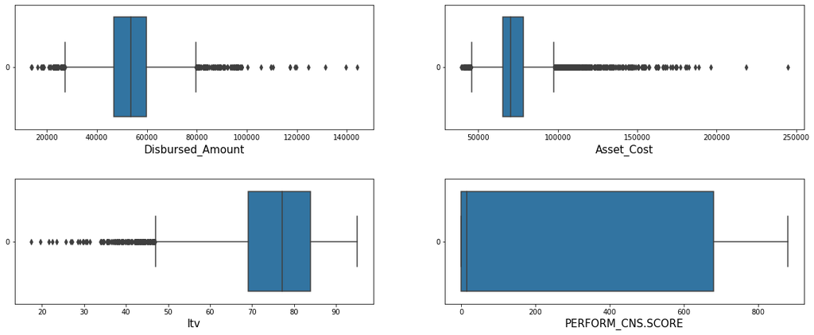

```python
## Before Outlier Treatment
plt.figure(figsize=(20,35))
plt.subplots_adjust(hspace=0.4)
plot_num = 1
for i in df_num.columns:
    ax = plt.subplot(8,2,plot_num)
    sns.boxplot(data=df_num[i],orient='h')
    plt.xlabel(i,fontdict={'fontsize':15})
    plot_num+=1
```

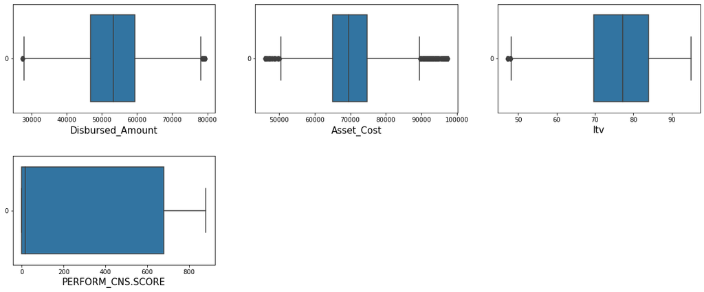

```python
## After Outlier Treatment with knn
plt.figure(figsize=(20,35))
plt.subplots_adjust(hspace=0.4)
plot_num = 1
for i in df_num.columns:
    ax = plt.subplot(8,3,plot_num)
    sns.boxplot(data=df[i],orient='h')
    plt.xlabel(i,fontdict={'fontsize':15})
    plot_num+=1
```

from above visulations we can observe that outliers replacement with knn is giving good results

```python
#from pandas_profiling import ProfileReport
```

```python
#profiling = ProfileReport(df)
```

```python
#profiling
```

# Visuvaliation results of default variable with demographic and other variables

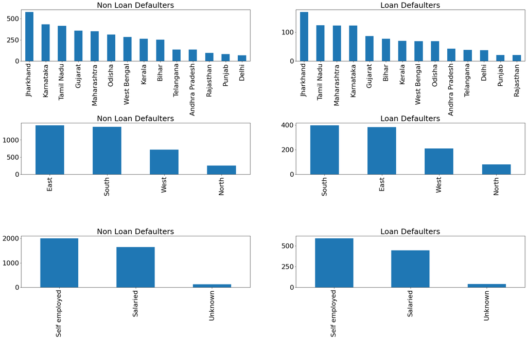

```python
plt.figure(figsize=(30,17))
plt.subplots_adjust(hspace=1.2)
plt.rcParams.update({'font.size': 22})
plt.subplot(3,2,1)
df[df['Loan_Default']==0]['State_Name'].value_counts().plot(kind='bar')
plt.title('Non Loan Defaulters', fontdict={'fontsize': 25})
plt.xticks(fontsize=22)
plt.yticks(fontsize=22)
plt.subplot(3,2,2)
df[df['Loan_Default']==1]['State_Name'].value_counts().plot(kind='bar')
plt.title('Loan Defaulters', fontdict={'fontsize':25})
plt.xticks(fontsize=22)
plt.yticks(fontsize=22)
plt.subplot(3,2,3)
df[df['Loan_Default']==0]['Region_Name'].value_counts().plot(kind='bar')
plt.title('Non Loan Defaulters', fontdict={'fontsize':25})
plt.xticks(fontsize=22)
plt.yticks(fontsize=22)
plt.subplot(3,2,4)
df[df['Loan_Default']==1]['Region_Name'].value_counts().plot(kind='bar',)
plt.title('Loan Defaulters',fontdict={'fontsize':25})
plt.xticks(fontsize=22)
plt.yticks(fontsize=22)
plt.subplot(3,2,5)
df[df['Loan_Default']==0]['Employment_Type'].value_counts().plot(kind='bar')
plt.title('Non Loan Defaulters', fontdict={'fontsize':25})
plt.xticks(fontsize=22)
plt.yticks(fontsize=22)
plt.subplot(3,2,6)
df[df['Loan_Default']==1]['Employment_Type'].value_counts().plot(kind='bar')
plt.title('Loan Defaulters', fontdict={'fontsize':25})
plt.xticks(fontsize=22)
plt.yticks(fontsize=22)
plt.show()
```

- Region wise: South has highest number of loan defaulters and next place is East
- Self Employed are highest loan defaulters as compared to Salaried.

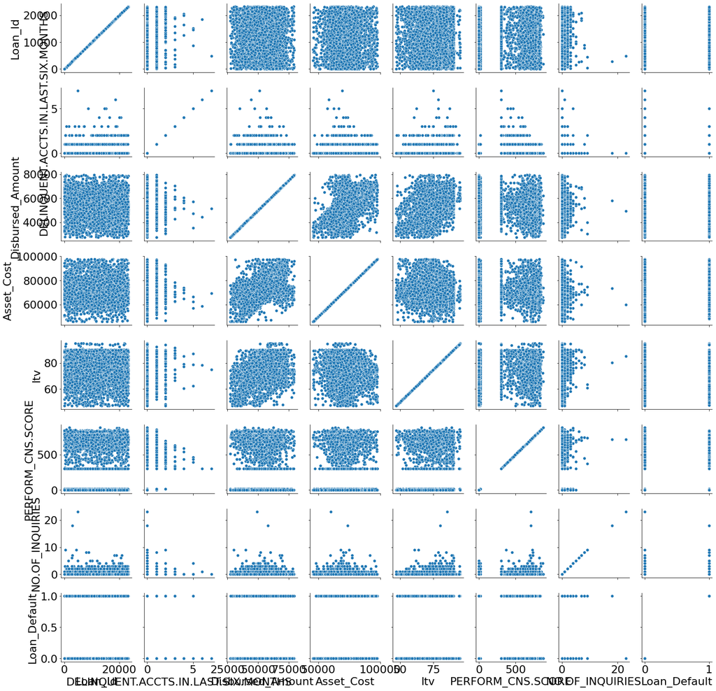

```python
g = sns.PairGrid(df)
g.map(sns.scatterplot)
```

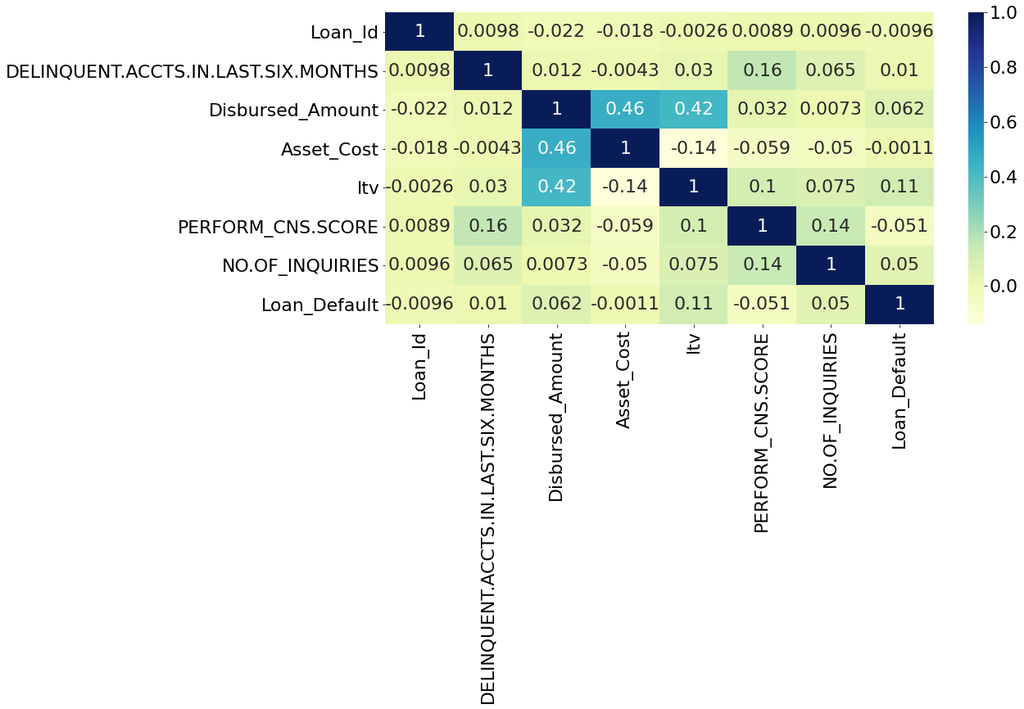

```python
plt.figure(figsize=(15,7))
sns.heatmap(df.corr(), cmap="YlGnBu", annot=True)
plt.xticks(fontsize=22)
plt.yticks(fontsize=22);
```

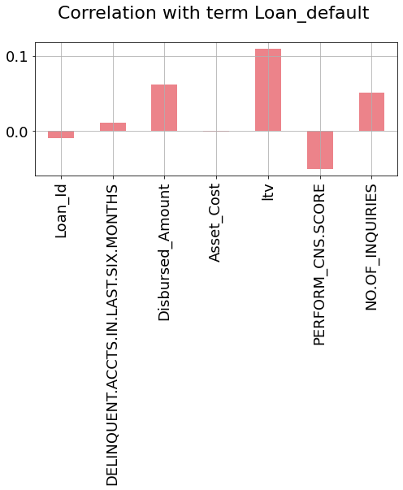

```python
correlations = df.corrwith(df.Loan_Default)
correlations = correlations[correlations!=1]
correlations.plot.bar(
        figsize = (8, 3),
        fontsize = 10,
        color = '#ec838a',
        rot = 45, grid = True)
plt.title('Correlation with term Loan_default \n',
horizontalalignment="center", fontstyle = "normal",
fontsize = "22", fontfamily = "sans-serif")
plt.xticks(rotation = 90)
plt.xticks(fontsize=18)
plt.yticks(fontsize=18);
```

# Statistical Analysis

## Now we can check the distribution of the features

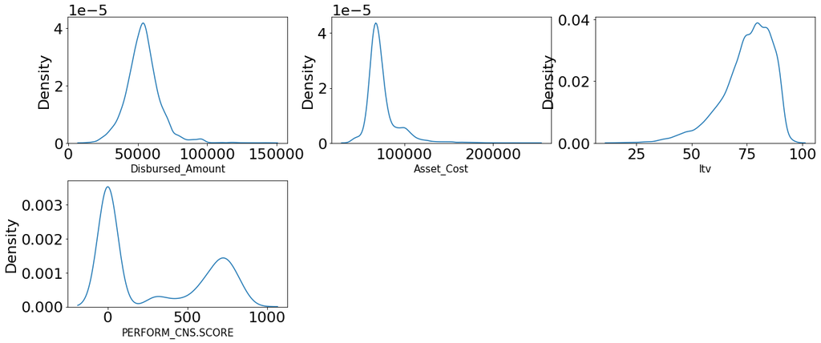

```python
plt.figure(figsize=(20,35),facecolor='white')
plt.subplots_adjust(hspace=0.3)
plot_num=1
for i in df_num.columns:
    ax=plt.subplot(8,3,plot_num)
    sns.kdeplot(df_num[i])
    plt.xlabel(i,fontdict={'fontsize':15})
    plot_num+=1
plt.show()
```

From above graph we can observe the right & left skewness of features, to overcome this we can try with transformation techniques.

```python
def trans_kde(i):
    plt.figure(figsize=(20,8),facecolor='white')
    plt.subplots_adjust(hspace=0.4)
    plt.subplot(2,3,1)
    sns.kdeplot(data=df_num[i])
    plt.title('Original',fontdict={'fontsize':15})
    plt.xlabel(i,fontdict={'fontsize':15})
    plt.subplot(2,3,2)
    sns.kdeplot(data=np.sqrt(df_num[i]))
    plt.title('Sqroot',fontdict={'fontsize':15})
    plt.xlabel(i,fontdict={'fontsize':15})
    plt.subplot(2,3,3)
    sns.kdeplot(data=(df_num[i])**2)
    plt.title('Square',fontdict={'fontsize':15})
    plt.xlabel(i,fontdict={'fontsize':15})
    plt.subplot(2,3,4)
    sns.kdeplot(data=np.log(df_num[i]))
    plt.title('Log',fontdict={'fontsize':15})
    plt.xlabel(i,fontdict={'fontsize':15})
    plt.subplot(2,3,5)
    sns.kdeplot(data=np.cbrt(df_num[i]))
    plt.title('Cuberoot',fontdict={'fontsize':15})
    plt.xlabel(i,fontdict={'fontsize':15})
    plt.show()
```

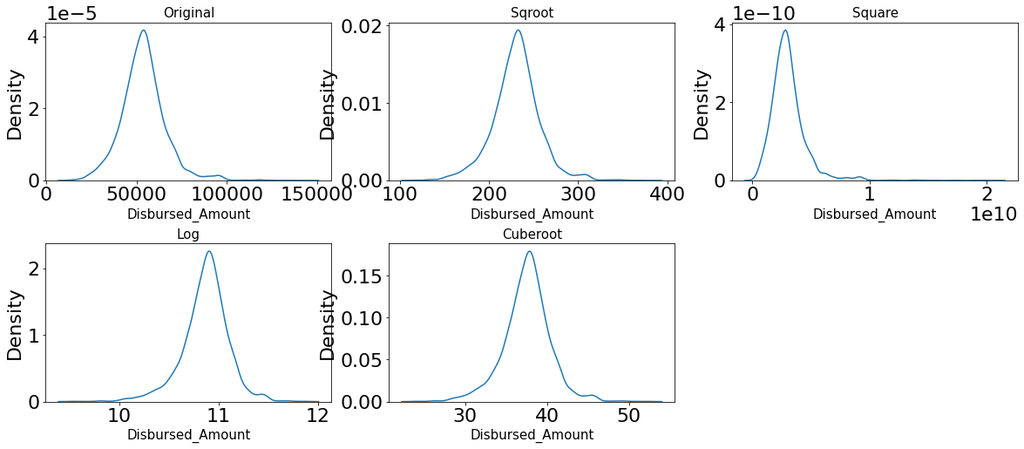

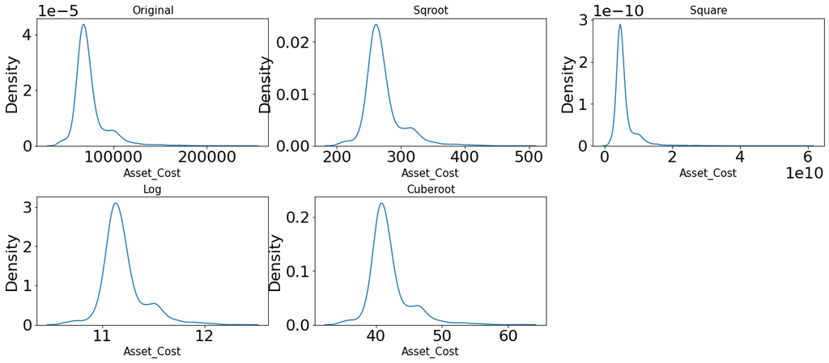

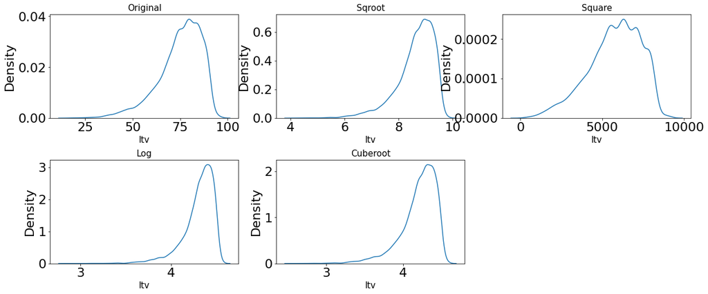

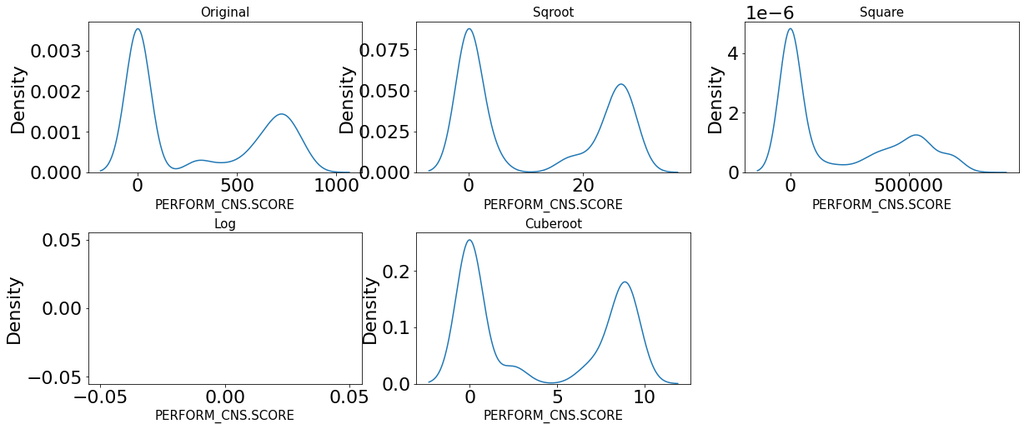

```python
for i in df_num.columns:
    trans_kde(i)
```

As we observe above transformations there is no much change

# Descriptive Statistics

```python
df.mean()
```

```
Loan_Id                                11655.539368
DELINQUENT.ACCTS.IN.LAST.SIX.MONTHS        0.106634
Disbursed_Amount                       53019.483072
Asset_Cost                             70514.002962
ltv                                       75.827717
PERFORM_CNS.SCORE                        292.938210
NO.OF_INQUIRIES                            0.205414
Loan_Default                               0.221533
dtype: float64
```

```python
df.median()
```

```
Loan_Id                                11731.00
DELINQUENT.ACCTS.IN.LAST.SIX.MONTHS        0.00
Disbursed_Amount                       53303.00
Asset_Cost                             69555.00
ltv                                       77.26
PERFORM_CNS.SCORE                         15.00
NO.OF_INQUIRIES                            0.00
Loan_Default                               0.00
dtype: float64
```

```python
df.std()
```

```
Loan_Id                                 6791.601515
DELINQUENT.ACCTS.IN.LAST.SIX.MONTHS        0.412440
Disbursed_Amount                       10030.934584
Asset_Cost                              8742.386023
ltv                                        9.840216
PERFORM_CNS.SCORE                        339.241870
NO.OF_INQUIRIES                            0.760733
Loan_Default                               0.415322
dtype: float64
```

```python
df.describe()
```

|  | Loan_Id | DELINQUENT.ACCTS.IN.LAST.SIX.MONTHS | Disbursed_Amount | Asset_Cost | ltv | PERFORM_CNS.SCORE | NO.OF_INQUIRIES | Loan_Default |
| --- | --- | --- | --- | --- | --- | --- | --- | --- |
| count | 4839.000000 | 4839.000000 | 4839.000000 | 4839.000000 | 4839.000000 | 4839.00000 | 4839.000000 | 4839.000000 |
| mean | 11655.539368 | 0.106634 | 53019.483072 | 70514.002962 | 75.827717 | 292.93821 | 0.205414 | 0.221533 |
| std | 6791.601515 | 0.412440 | 10030.934584 | 8742.386023 | 9.840216 | 339.24187 | 0.760733 | 0.415322 |
| min | 2.000000 | 0.000000 | 27281.000000 | 45862.000000 | 47.100000 | 0.00000 | 0.000000 | 0.000000 |
| 25% | 5748.000000 | 0.000000 | 46747.500000 | 65000.000000 | 69.640000 | 0.00000 | 0.000000 | 0.000000 |
| 50% | 11731.000000 | 0.000000 | 53303.000000 | 69555.000000 | 77.260000 | 15.00000 | 0.000000 | 0.000000 |
| 75% | 17573.000000 | 0.000000 | 59344.500000 | 74799.000000 | 83.920000 | 679.00000 | 0.000000 | 0.000000 |
| max | 23312.000000 | 7.000000 | 79533.000000 | 97591.000000 | 94.980000 | 879.00000 | 23.000000 | 1.000000 |

```python
df.describe(include='O')
```

|  | Region_Name | State_Name | City_Name | Employment_Type | Date_of_Birth | DisbursalDate | CREDIT.HISTORY.LENGTH |
| --- | --- | --- | --- | --- | --- | --- | --- |
| count | 4839 | 4839 | 4839 | 4839 | 4839 | 4839 | 4839 |
| unique | 4 | 14 | 24 | 3 | 3038 | 83 | 168 |
| top | East | Jharkhand | Bhubaneshwar | Self employed | 01-01-1987 | 31-10-2018 | 0yrs 0mon |
| freq | 1811 | 747 | 383 | 2587 | 55 | 175 | 2452 |

# Hypothesis Testing

### Normality Test

Hypothesis testing on Normality using ShapiroTest Null Hypothesis H0: Gaussian Distribution: If P>0.05 accept H0 Alternative Hypothesis H1: Not a Gaussian Distribution: If P<0.05 accept H1

```python
from scipy.stats import shapiro
```

```python
stat, p = shapiro(df.Loan_Default)
print('stat=%.3f, p=%.3f' % (stat, p))
if p > 0.05:
    print('Probably Gaussian')
else:
    print('Probably not Gaussian')
```

```
stat=0.512, p=0.000
Probably not Gaussian
```

Hece P value is < 0.05 we reject the Null Hypothesis So we conlude that Predicted value is not following the Normal Distribution Hence we go for the Non-Peramateric test to know the relation between Targeted and Independent Variables.

Tests for Relationship between two variables

Hypothesis testing for relation Null Hypothesis H0: There is no relation b/w independent variables and Target/dependent variable 'Loan_Default'. If P>0.05 accept H0 Alternative Hypothesis H1: There is a relation b/w independent variables and Target/dependent variable 'Loan_Default'.If P<0.05 accept H1

### Correlation Test

```python
import scipy.stats as stats
from scipy.stats import chi2_contingency
from scipy import stats
from statsmodels.stats.weightstats import ztest as ztest
```

Returns for Chi2 chi2 : The test statistic. p : The p-value of the test dof : Degrees of freedom expected : ndarray, same shape as `observed` The expected frequencies, based on the marginal sums of the table.

```python
df[df['Loan_Default']==1]['Loan_Default'].value_counts()
```

```
1.0    1072
Name: Loan_Default, dtype: int64
```

```python
chi2_contingency(pd.crosstab(df.Loan_Default,df['Region_Name']))
```

```
(2.0799142961460264,
 0.5559869136155713,
 3,
 array([[1409.80305848,  256.11551974, 1384.11365985,  716.96776193],
        [ 401.19694152,   72.88448026,  393.88634015,  204.03223807]]))
```

```python
chi2_contingency(pd.crosstab(df.Loan_Default,df['State_Name']))
```

```
(24.933639877360207,
 0.02355148469248609,
 13,
 array([[137.78859268, 255.33705311,  83.29592891, 346.41764827,
         581.51456913, 432.04897706, 258.45091961, 370.55011366,
         298.1527175 ,  81.73899566,  91.08059516, 418.81504443,
         137.01012606, 274.79871874],
        [ 39.21140732,  72.66294689,  23.70407109,  98.58235173,
         165.48543087, 122.95102294,  73.54908039, 105.44988634,
          84.8472825 ,  23.26100434,  25.91940484, 119.18495557,
          38.98987394,  78.20128126]]))
```

```python
chi2_contingency(pd.crosstab(df.Loan_Default,df['City_Name']))
```

```
(42.886948945246104,
 0.007142556636683216,
 23,
 array([[108.20686092, 115.21306055, 150.24405869, 298.1527175 ,
         133.89625956, 150.24405869,  83.29592891, 137.01012606,
          91.08059516, 291.9249845 , 126.1115933 , 274.79871874,
          81.73899566, 129.22545981, 118.32692705, 152.57945857,
         137.78859268, 255.33705311, 137.01012606, 289.58958462,
         122.9977268 , 132.33932631, 115.21306055, 134.67472618],
        [ 30.79313908,  32.78693945,  42.75594131,  84.8472825 ,
          38.10374044,  42.75594131,  23.70407109,  38.98987394,
          25.91940484,  83.0750155 ,  35.8884067 ,  78.20128126,
          23.26100434,  36.77454019,  33.67307295,  43.42054143,
          39.21140732,  72.66294689,  38.98987394,  82.41041538,
          35.0022732 ,  37.66067369,  32.78693945,  38.32527382]]))
```

```python
chi2_contingency(pd.crosstab(df.Loan_Default,df['Employment_Type']))
```

```
(2.542693699889994,
 0.2804536383246697,
 2,
 array([[1626.99524695, 2013.89315974,  126.1115933 ],
        [ 463.00475305,  573.10684026,   35.8884067 ]]))
```

```python
chi2_contingency(pd.crosstab(df.Loan_Default,df['Date_of_Birth']))
```

```
(3003.7431552326925,
 0.6626572827952191,
 3037,
 array([[0.77846663, 3.1138665 , 1.55693325, ..., 0.77846663, 0.77846663,
         1.55693325],
        [0.22153337, 0.8861335 , 0.44306675, ..., 0.22153337, 0.22153337,
         0.44306675]]))
```

```python
chi2_contingency(pd.crosstab(df.Loan_Default,df['DisbursalDate']))
```

[output not shown]

```python
chi2_contingency(pd.crosstab(df.Loan_Default,df['CREDIT.HISTORY.LENGTH']))
```

[output not shown]

[output cut: 32 more lines]

[output not shown]

```python
chi2_contingency(pd.crosstab(df.Loan_Default,df['DELINQUENT.ACCTS.IN.LAST.SIX.MONTHS']))
```

```
(6.897666656732954,
 0.43961207928505,
 7,
 array([[3.45405642e+03, 2.53780120e+02, 4.28156644e+01, 9.34159950e+00,
         3.11386650e+00, 2.33539988e+00, 7.78466625e-01, 7.78466625e-01],
        [9.82943583e+02, 7.22198801e+01, 1.21843356e+01, 2.65840050e+00,
         8.86133499e-01, 6.64600124e-01, 2.21533375e-01, 2.21533375e-01]]))
```

Returns for Pearsonr ------- r : Pearson's correlation coefficient. p-value : Two-tailed p-value.

```python
stats.pearsonr(df.Loan_Default,df['DELINQUENT.ACCTS.IN.LAST.SIX.MONTHS'])
```

```
(0.010484494055106212, 0.4659015631678842)
```

```python
stats.pearsonr(df.Loan_Default,df['Disbursed_Amount'])
```

```
(0.06166982553814517, 1.7634555906279357e-05)
```

```python
stats.pearsonr(df.Loan_Default,df['Asset_Cost'])
```

```
(-0.0011062182170832342, 0.9386777092580145)
```

```python
stats.pearsonr(df.Loan_Default,df['ltv'])
```

```
(0.1093722135055867, 2.3624938435758568e-14)
```

```python
stats.pearsonr(df.Loan_Default,df['PERFORM_CNS.SCORE'])
```

```
(-0.05136491732082913, 0.00035085735942068754)
```

```python
stats.pearsonr(df.Loan_Default,df['NO.OF_INQUIRIES'])
```

```
(0.05024065699635293, 0.0004719492787869201)
```

```python
df1 = df.drop(columns=["Date_of_Birth","CREDIT.HISTORY.LENGTH","DELINQUENT.ACCTS.IN.LAST.SIX.MONTHS", "Asset_Cost","State_Name","City_Name"])
```

```python
df1['DisbursalDate'] = pd.to_datetime(df1.DisbursalDate)
```

```python
df1.info()
```

```
<class 'pandas.core.frame.DataFrame'>
Int64Index: 4839 entries, 0 to 4838
Data columns (total 9 columns):
 #   Column             Non-Null Count  Dtype
---  ------             --------------  -----
 0   Loan_Id            4839 non-null   int64
 1   Region_Name        4839 non-null   object
 2   Employment_Type    4839 non-null   object
 3   DisbursalDate      4839 non-null   datetime64[ns]
 4   Disbursed_Amount   4839 non-null   float64
 5   ltv                4839 non-null   float64
 6   PERFORM_CNS.SCORE  4839 non-null   float64
 7   NO.OF_INQUIRIES    4839 non-null   float64
 8   Loan_Default       4839 non-null   float64
dtypes: datetime64[ns](1), float64(5), int64(1), object(2)
memory usage: 507.1+ KB
```

```python
df1.head()
```

|  | Loan_Id | Region_Name | Employment_Type | DisbursalDate | Disbursed_Amount | ltv | PERFORM_CNS.SCORE | NO.OF_INQUIRIES | Loan_Default |
| --- | --- | --- | --- | --- | --- | --- | --- | --- | --- |
| 0 | 194 | South | Salaried | 2018-08-08 | 57213.0 | 83.38 | 0.0 | 0.0 | 1.0 |
| 1 | 2285 | South | Salaried | 2018-10-25 | 45659.0 | 57.44 | 738.0 | 0.0 | 0.0 |
| 2 | 4485 | South | Self employed | 2018-07-09 | 56759.0 | 74.83 | 0.0 | 0.0 | 0.0 |
| 3 | 14129 | South | Salaried | 2018-09-24 | 53612.0 | 59.82 | 17.0 | 0.0 | 0.0 |
| 4 | 19639 | South | Unknown | 2018-10-23 | 55259.0 | 73.35 | 0.0 | 0.0 | 1.0 |

```python
df1.shape
```

```
(4839, 9)
```

### One Hot Encoding

```python
data = pd.get_dummies(df1)
```

```python
data.shape
```

```
(4839, 14)
```

```python
data
```

|  | Loan_Id | DisbursalDate | Disbursed_Amount | ltv | PERFORM_CNS.SCORE | NO.OF_INQUIRIES | Loan_Default | Region_Name_East | Region_Name_North | Region_Name_South | Region_Name_West | Employment_Type_Salaried | Employment_Type_Self employed | Employment_Type_Unknown |
| --- | --- | --- | --- | --- | --- | --- | --- | --- | --- | --- | --- | --- | --- | --- |
| 0 | 194 | 2018-08-08 | 57213.0 | 83.38 | 0.0 | 0.0 | 1.0 | 0 | 0 | 1 | 0 | 1 | 0 | 0 |
| 1 | 2285 | 2018-10-25 | 45659.0 | 57.44 | 738.0 | 0.0 | 0.0 | 0 | 0 | 1 | 0 | 1 | 0 | 0 |
| 2 | 4485 | 2018-07-09 | 56759.0 | 74.83 | 0.0 | 0.0 | 0.0 | 0 | 0 | 1 | 0 | 0 | 1 | 0 |
| 3 | 14129 | 2018-09-24 | 53612.0 | 59.82 | 17.0 | 0.0 | 0.0 | 0 | 0 | 1 | 0 | 1 | 0 | 0 |
| 4 | 19639 | 2018-10-23 | 55259.0 | 73.35 | 0.0 | 0.0 | 1.0 | 0 | 0 | 1 | 0 | 0 | 0 | 1 |
| ... | ... | ... | ... | ... | ... | ... | ... | ... | ... | ... | ... | ... | ... | ... |
| 4834 | 1346 | 2018-08-30 | 46349.0 | 77.20 | 0.0 | 0.0 | 0.0 | 0 | 1 | 0 | 0 | 0 | 1 | 0 |
| 4835 | 4696 | 2018-10-29 | 39239.0 | 70.04 | 726.0 | 0.0 | 0.0 | 0 | 1 | 0 | 0 | 1 | 0 | 0 |
| 4836 | 19519 | 2018-08-28 | 47349.0 | 84.60 | 300.0 | 0.0 | 0.0 | 0 | 1 | 0 | 0 | 0 | 1 | 0 |
| 4837 | 12709 | 2018-10-28 | 51931.0 | 80.00 | 0.0 | 1.0 | 1.0 | 0 | 1 | 0 | 0 | 0 | 1 | 0 |
| 4838 | 16272 | 2018-10-23 | 40894.0 | 66.22 | 424.0 | 0.0 | 1.0 | 0 | 1 | 0 | 0 | 0 | 1 | 0 |

4839 rows × 14 columns

# Percentage of Loan Defaulters

```python
 df['Loan_Default'].value_counts(normalize=True).mul(100).round(2)
```

```
0.0    77.85
1.0    22.15
Name: Loan_Default, dtype: float64
```

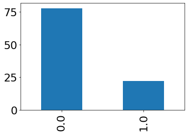

```python
 df['Loan_Default'].value_counts(normalize=True).mul(100).round(2).plot.bar()
```

as per the default and non default percentage we can conclude that Data is imbalanced

# Balancing

Because of Data is imbalance, we are using SMOTE technique to balance the Dataset

```python
from imblearn.over_sampling import SMOTE
sm = SMOTE(sampling_strategy='minority', random_state=69)
oversampled_X, oversampled_Y = sm.fit_resample(data.drop(['DisbursalDate','Loan_Default'], axis=1), data['Loan_Default'])
oversampled = pd.concat([pd.DataFrame(oversampled_Y), pd.DataFrame(oversampled_X)], axis=1)
```

```python
oversampled.head()
```

|  | Loan_Default | Loan_Id | Disbursed_Amount | ltv | PERFORM_CNS.SCORE | NO.OF_INQUIRIES | Region_Name_East | Region_Name_North | Region_Name_South | Region_Name_West | Employment_Type_Salaried | Employment_Type_Self employed | Employment_Type_Unknown |
| --- | --- | --- | --- | --- | --- | --- | --- | --- | --- | --- | --- | --- | --- |
| 0 | 1.0 | 194 | 57213.0 | 83.38 | 0.0 | 0.0 | 0 | 0 | 1 | 0 | 1 | 0 | 0 |
| 1 | 0.0 | 2285 | 45659.0 | 57.44 | 738.0 | 0.0 | 0 | 0 | 1 | 0 | 1 | 0 | 0 |
| 2 | 0.0 | 4485 | 56759.0 | 74.83 | 0.0 | 0.0 | 0 | 0 | 1 | 0 | 0 | 1 | 0 |
| 3 | 0.0 | 14129 | 53612.0 | 59.82 | 17.0 | 0.0 | 0 | 0 | 1 | 0 | 1 | 0 | 0 |
| 4 | 1.0 | 19639 | 55259.0 | 73.35 | 0.0 | 0.0 | 0 | 0 | 1 | 0 | 0 | 0 | 1 |

```python
x = oversampled.drop('Loan_Default',axis=1)
y = oversampled['Loan_Default']
```

## Standardizing the data

```python
from sklearn.preprocessing import StandardScaler
sc = StandardScaler()
for col in x:
    x[col] = sc.fit_transform(x[col].values.reshape(-1,1))
```

```python
x.head()
```

|  | Loan_Id | Disbursed_Amount | ltv | PERFORM_CNS.SCORE | NO.OF_INQUIRIES | Region_Name_East | Region_Name_North | Region_Name_South | Region_Name_West | Employment_Type_Salaried | Employment_Type_Self employed | Employment_Type_Unknown |
| --- | --- | --- | --- | --- | --- | --- | --- | --- | --- | --- | --- | --- |
| 0 | -1.665758 | 0.377621 | 0.745549 | -0.875981 | -0.302252 | -0.637277 | -0.219399 | 1.575283 | -0.398621 | 1.397209 | -0.912982 | -0.151481 |
| 1 | -1.357702 | -0.775164 | -2.078812 | 1.465443 | -0.302252 | -0.637277 | -0.219399 | 1.575283 | -0.398621 | 1.397209 | -0.912982 | -0.151481 |
| 2 | -1.033588 | 0.332323 | -0.185379 | -0.875981 | -0.302252 | -0.637277 | -0.219399 | 1.575283 | -0.398621 | -0.715712 | 1.095312 | -0.151481 |
| 3 | 0.387213 | 0.018336 | -1.819676 | -0.822046 | -0.302252 | -0.637277 | -0.219399 | 1.575283 | -0.398621 | 1.397209 | -0.912982 | -0.151481 |
| 4 | 1.198973 | 0.182663 | -0.346523 | -0.875981 | -0.302252 | -0.637277 | -0.219399 | 1.575283 | -0.398621 | -0.715712 | -0.912982 | 6.601506 |

```python
from sklearn.model_selection import train_test_split
```

```python
xtrain,xtest,ytrain,ytest = train_test_split(x,y,test_size=0.3,random_state=1)
```

```python
ytrain.value_counts()
```

```
1.0    2651
0.0    2622
Name: Loan_Default, dtype: int64
```

```python
print('xtrain :',xtrain.shape)
print('xtest  :',xtest.shape)
print('ytrain :',ytrain.shape)
print('ytest  :',ytest.shape)
```

```
xtrain : (5273, 12)
xtest  : (2261, 12)
ytrain : (5273,)
ytest  : (2261,)
```

# Linear Regression

```python
from sklearn.linear_model import LinearRegression,LogisticRegression
from sklearn.metrics import r2_score,mean_squared_error,accuracy_score,precision_score,recall_score,f1_score,classification_report
import statsmodels.api as sm
```

```python
lm = LinearRegression(fit_intercept=True)
price_lm =lm.fit(xtrain,ytrain)
price_lm
```

```
LinearRegression()
```

```python
lm.coef_
```

```
array([-0.01098815,  0.00297333,  0.0466737 , -0.02761692,  0.01569938,
       -0.21980104, -0.11254424, -0.219505  , -0.17805245, -0.16688222,
       -0.14815704, -0.05183766])
```

```python
lm.intercept_
```

```
0.5041041039729073
```

```python
y_pred = lm.predict(xtest)
y_pred
```

```
array([0.71726997, 0.6070194 , 0.38428972, ..., 0.27770212, 0.33420392,
       0.40334617])
```

```python
##Ols Method
price_lr = sm.OLS(ytrain,xtrain).fit()
```

```python
print(price_lr.params)
```

```
Loan_Id                         -0.011973
Disbursed_Amount                 0.006860
ltv                              0.048149
PERFORM_CNS.SCORE               -0.031011
NO.OF_INQUIRIES                  0.018380
Region_Name_East                -0.217475
Region_Name_North               -0.108794
Region_Name_South               -0.219673
Region_Name_West                -0.185355
Employment_Type_Salaried        -0.158539
Employment_Type_Self employed   -0.143636
Employment_Type_Unknown         -0.049681
dtype: float64
```

```python
price_lr.summary2()
```

| Model: | OLS | Adj. R-squared (uncentered): | 0.182 |
| --- | --- | --- | --- |
| Dependent Variable: | Loan_Default | AIC: | 10289.2913 |
| Date: | 2022-04-28 13:11 | BIC: | 10368.1356 |
| No. Observations: | 5273 | Log-Likelihood: | -5132.6 |
| Df Model: | 12 | F-statistic: | 98.92 |
| Df Residuals: | 5261 | Prob (F-statistic): | 8.49e-222 |
| R-squared (uncentered): | 0.184 | Scale: | 0.41113 |

|  | Coef. | Std.Err. | t | P>\|t\| | [0.025 | 0.975] |
| --- | --- | --- | --- | --- | --- | --- |
| Loan_Id | -0.0120 | 0.0088 | -1.3544 | 0.1757 | -0.0293 | 0.0054 |
| Disbursed_Amount | 0.0069 | 0.0097 | 0.7063 | 0.4800 | -0.0122 | 0.0259 |
| ltv | 0.0481 | 0.0099 | 4.8709 | 0.0000 | 0.0288 | 0.0675 |
| PERFORM_CNS.SCORE | -0.0310 | 0.0090 | -3.4394 | 0.0006 | -0.0487 | -0.0133 |
| NO.OF_INQUIRIES | 0.0184 | 0.0091 | 2.0089 | 0.0446 | 0.0004 | 0.0363 |
| Region_Name_East | -0.2175 | 0.0123 | -17.6658 | 0.0000 | -0.2416 | -0.1933 |
| Region_Name_North | -0.1088 | 0.0097 | -11.1984 | 0.0000 | -0.1278 | -0.0897 |
| Region_Name_South | -0.2197 | 0.0123 | -17.9320 | 0.0000 | -0.2437 | -0.1957 |
| Region_Name_West | -0.1854 | 0.0113 | -16.4455 | 0.0000 | -0.2075 | -0.1633 |
| Employment_Type_Salaried | -0.1585 | 0.0137 | -11.5401 | 0.0000 | -0.1855 | -0.1316 |
| Employment_Type_Self employed | -0.1436 | 0.0138 | -10.3983 | 0.0000 | -0.1707 | -0.1166 |
| Employment_Type_Unknown | -0.0497 | 0.0095 | -5.2067 | 0.0000 | -0.0684 | -0.0310 |

| Omnibus: | 1460.900 | Durbin-Watson: | 0.758 |
| --- | --- | --- | --- |
| Prob(Omnibus): | 0.000 | Jarque-Bera (JB): | 697.385 |
| Skew: | 0.744 | Prob(JB): | 0.000 |
| Kurtosis: | 2.021 | Condition No.: | 3 |

```python
# Predict Values Test Dataset
y_pred_test = price_lr.predict(xtest)
y_pred_train= price_lr.predict(xtrain)
```

```python
# R Square for Train Data
np.abs(r2_score(ytest,y_pred_test))
```

```
0.5630938622188375
```

```python
# Calculating Root Mean Squred Error for Train Data
np.sqrt(mean_squared_error(ytrain,y_pred_train))
```

```
0.6404680252566598
```

```python
# Calculating Root Mean Squred Error for Test Data
np.sqrt(mean_squared_error(ytest,y_pred_test))
```

```
0.6250673395976256
```

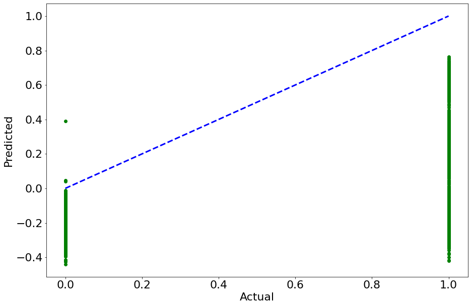

```python
plt.figure(figsize=(15,10))
plt.scatter(ytrain,y_pred_train,c='green')
plt.plot([ytrain.min(),ytrain.max()],[ytrain.min(),ytrain.max()],'k--',c='blue',lw=3)
plt.xlabel('Actual')
plt.ylabel('Predicted')
```